# Taller 1 - corte 3

Sergio Cadavid, Guirlessa De La Hoz, Valerie Martínez, Mariangel Mercado, Alex Teran

April 2025

# Punto 1

Sea $X_1, X_2, ..., X_n$ una muestra de $n$ variables aleatorias de una distribución uniforme $[0, \theta]$.

#### 1. Calcule un estimador insesgado $\hat{\theta}_1$ de $\theta$ basado en el método de momentos.

##### Solución:

Tenemos que:

$$X \sim \text{Uniforme } (0, \theta), \quad f_X(x) =
\begin{cases}
\frac{1}{\theta} & \text{si } 0 \leq x \leq \theta \\
0 & \text{en otro caso}
\end{cases}$$

El valor esperado de $X$:

$$E[X] = \int_{-\infty}^{\infty} x f_X(x) dx = \int_0^\theta x \cdot
\frac{1}{\theta} dx = \frac{1}{\theta} \int_0^\theta x dx$$

$$E[X] = \frac{1}{\theta} \left[ \frac{x^2}{2} \right]_0^\theta =
\frac{1}{\theta} \cdot \frac{\theta^2}{2} = \frac{\theta}{2}$$

Dada la muestra $X_1, X_2, \dots, X_n$, el primer momento muestral es la media muestral:

$$\bar{X} = \frac{1}{n} \sum_{i=1}^n X_i$$

Igualar el primer momento poblacional ($E[X] = \frac{\theta}{2}$) con el primer momento muestral ($\bar{X}$):

$$\frac{\theta}{2} = \bar{X} \Rightarrow \theta = 2 \bar{X}$$

$\hat{\theta}_1 = 2 \bar{X}$

Calculando $E[\hat{\theta}_1]$

$$E[\hat{\theta}_1] = E[2 \bar{X}] = 2 E[\bar{X}]$$

$$\bar{X} = \frac{1}{n} \sum_{i=1}^n X_i \quad \text{(por la linealidad de
la esperanza)}$$

$$E[\bar{X}] = \frac{1}{n} \sum_{i=1}^n E[X_i] = \frac{1}{n} \cdot n E[X]
= E[X]$$

$$E[X] = \frac{\theta}{2} \Rightarrow E[\hat{\theta}_1] = 2 \cdot
\frac{\theta}{2} = \theta$$

$$E[\hat{\theta}_1] = \theta \Rightarrow \hat{\theta}_1 \text{ es
insesgado}$$

$$\hat{\theta}_1 = \frac{2}{n} \sum_{i=1}^n X_i$$

#### 2. Calcule el estimador de máxima verosimilitud $\hat{\theta}_2$ de $\theta$. ¿Es sesgado?

##### Solución:

Dado que los $X_i \sim U(0, \theta)$, la función de densidad conjunta es:

$$f(x_1, ..., x_n; \theta) = \begin{cases}
\frac{1}{\theta^n} & \text{si } 0 \leq x_i \leq \theta \text{ para
todo } i \\
0 & \text{en otro caso}
\end{cases}$$

Esto equivale a:

$$L(\theta) = \frac{1}{\theta^n} \quad \text{si } \theta \geq \max(X_1,
..., X_n)$$

La función decrece con $\theta$, por lo tanto:

$$\hat{\theta}_2 = \max(X_1, ..., X_n)$$

Calculamos su esperanza:

$$E[\hat{\theta}_2] = E[\max(X_1, ..., X_n)] = \frac{n}{n+1}\theta \quad
\Rightarrow \text{es sesgado.}$$

#### 3. Sea $m = \min(X_1, X_2, ..., X_n)$ el mínimo valor de la muestra. Calcule $E(m)$ y deduzca un estimador insesgado $\hat{\theta}_3$ de $\theta$.

##### Solución:

Sea $m = \min(X_1, ..., X_n)$

Función de densidad del mínimo:

$$f_m(x) = \frac{n}{\theta}(1 - \frac{x}{\theta})^{n-1}$$

Esperanza:

$$E[m] = \frac{\theta}{n+1} \Rightarrow \hat{\theta}_3 = (n+1) \cdot m$$

Entonces $E[\hat{\theta}_3] = \theta$, por lo tanto, es **insesgado**.

#### 4. Calcule la varianza de $\hat{\theta}_1, \hat{\theta}_2$ y $\hat{\theta}_3$.

##### Solución:

**Para $\hat{\theta}_1 = 2\bar{X}$:**

$$Var(\hat{\theta}_1) = 4 \cdot \frac{Var(X)}{n} = 4 \cdot
\frac{\theta^2}{12n} = \frac{\theta^2}{3n}$$

**Para $\hat{\theta}_2 = \max(X_1, ..., X_n)$:**

$$E[M] = \frac{n}{n+1}\theta, \quad E[M^2] = \frac{n\theta^2}{n+2}$$

$$Var(\hat{\theta}_2) = \frac{n\theta^2}{(n+1)^2(n+2)}$$

**Para $\hat{\theta}_3 = (n+1)\cdot m$:**

# Punto 2

#### 1. En un bucle generar 10000 muestras aleatorias de tamaño n = 100 de una variable uniforme con parámetro 8 (ver función runif)

#### 2. Calcular $\hat{\theta}_1$, $\hat{\theta}_2$, $\hat{\theta}_3$ para cada muestra en 3 vectores que llamará theta1, theta2 y theta3.

```r
set.seed(123) #Semilla para reproductibidad
n <- 100 #Tamaño de muestra
num_muestras <- 10000 #Número muestras

#Vectores para los estimadores
theta1 <- numeric(num_muestras)
theta2 <- numeric(num_muestras)
theta3 <- numeric(num_muestras)

#Bucle para generar las muestras y calcular los estimadores según los teóricos
for (i in 1:num_muestras) {
  muestra <- runif(n, min = 0, max = 8)
  theta1[i] <- 2 * mean(muestra)
  theta2[i] <- max(muestra)
  theta3[i] <- (n + 1)* min(muestra)
}
```

#### 3. Dibuje los histogramas de los 3 estimadores. Utilice par(mfrow=c(1,3)) para que queden los 3 en la misma figura.

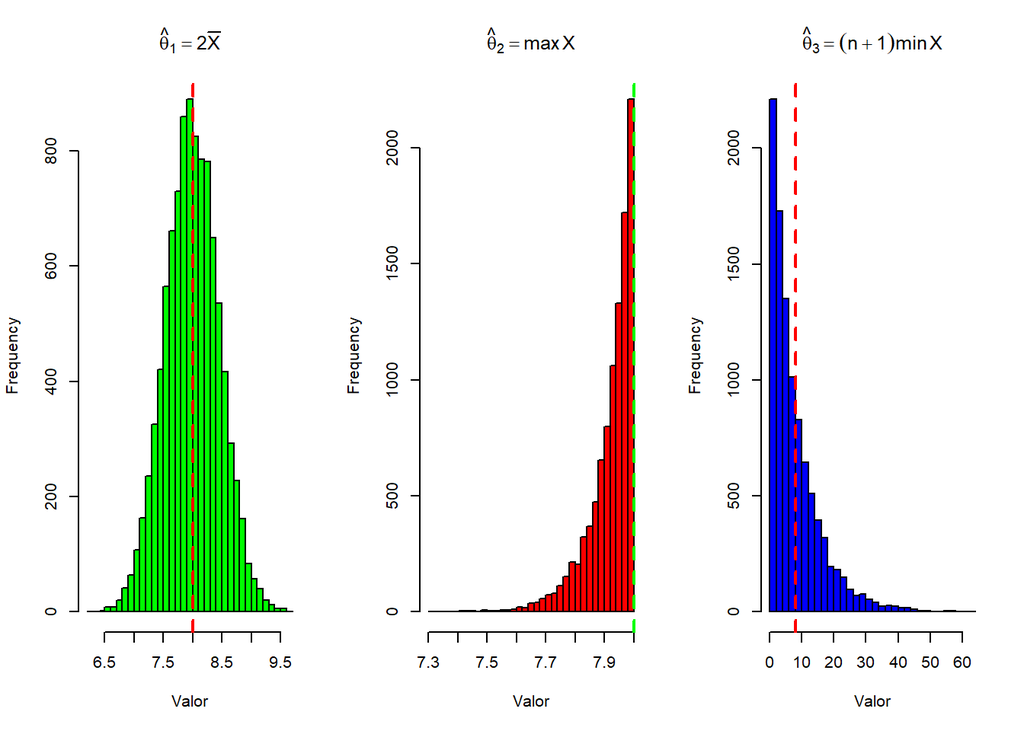

```r
# Valor real de theta
theta_real <- 8

par(mfrow = c(1, 3))

hist(theta1, main = expression(hat(theta)[1] == 2 * bar(X)), col = "green", xlab = "Valor", breaks = 40)
abline(v = theta_real, col = "red", lwd = 2, lty = 2)
hist(theta2, main = expression(hat(theta)[2] == max(X)), col = "red", xlab = "Valor", breaks = 40)
abline(v = theta_real, col = "green", lwd = 2, lty = 2)
hist(theta3, main = expression(hat(theta)[3] == (n+1) * min(X)), col = "blue", xlab = "Valor", breaks = 40)
abline(v = theta_real, col = "red", lwd = 2, lty = 2)
```

```r
par(mfrow = c(1,1))
```

#### 4. Unir los 3 vectores con los estimadores en una matriz. Utilice tidyverse.

```r
library(tidyverse)
estimadores <- tibble(
  theta1 = theta1,
  theta2 = theta2,
  theta3 = theta3
)
```

#### 5. Estimar el sesgo y la varianza para los 3 estimadores. Compare con los valores teóricos calculados.

```r
# Funciones auxiliares para hallar el sesgo y varianza más rápido
sesgo <- function(est, real) mean(est) - real
varianza <- function(est) var(est)

# Calcular sesgo y varianza
resultados <- tibble(
  Estimador = c("theta1", "theta2", "theta3"),
  Sesgo = c(sesgo(theta1, theta_real),
            sesgo(theta2, theta_real),
            sesgo(theta3, theta_real)),
  Varianza = c(varianza(theta1),
               varianza(theta2),
               varianza(theta3))
)

print(resultados)
```

```
## # A tibble: 3 × 3
##   Estimador    Sesgo Varianza
##   <chr>        <dbl>    <dbl>
## 1 theta1    -0.00754  0.210
## 2 theta2    -0.0800   0.00630
## 3 theta3    -0.0524  61.8
```

#### 6. Haga una gráfica de cajas y bigotes de la matriz, que incluya los 3 estimadores y trace una línea horizontal mostrando el valor real del parámetro θ.

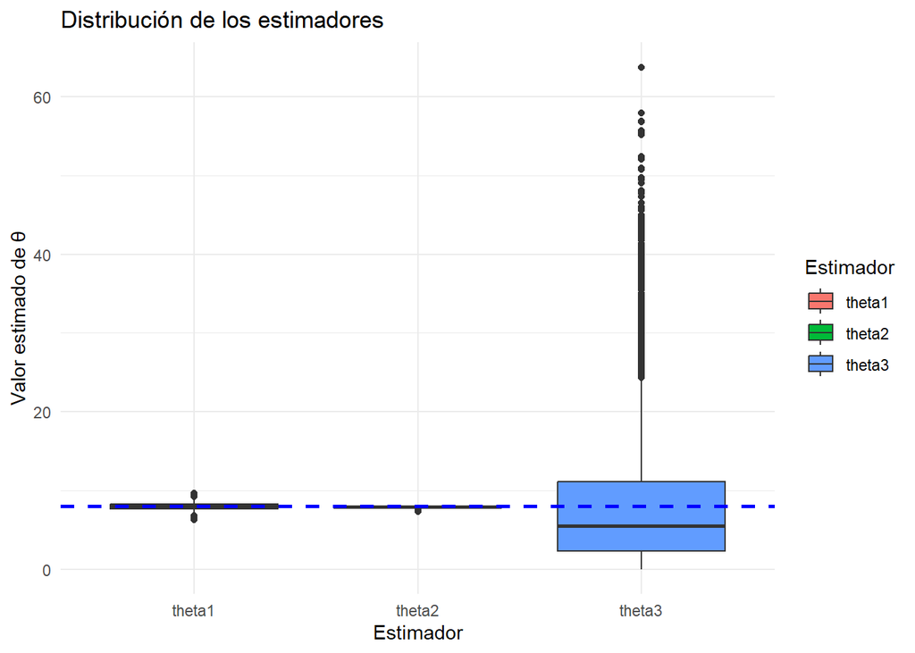

```r
# Convertimos a formato largo
estimadores_long <- estimadores %>%
  pivot_longer(cols = everything(), names_to = "Estimador", values_to = "Valor")

# Gráfico
ggplot(estimadores_long, aes(x = Estimador, y = Valor, fill = Estimador)) +
  geom_boxplot() +
  geom_hline(yintercept = 8, linetype = "dashed", color = "blue", size = 1) +
  labs(title = "Distribución de los estimadores",
       y = "Valor estimado de θ") +
  theme_minimal()
```

#### 7. Concluya y agregue comentarios que muestren su entendimiento sobre los estimadores.

En primer lugar, se puede observar que la caja correspondiente al estimador theta 1 se encuentra centrada en el valor real de theta, lo cual indica que este estimador es insesgado. Además, dado que la altura de la caja no es grande, se evidencia que presenta una varianza reducida, lo que implica una alta precisión. Por lo tanto, se puede concluir que theta 1 es un estimador preciso, consistente y eficiente.

En segundo lugar, respecto al estimador theta 2, su caja se encuentra ligeramente por debajo del valor real de theta, lo cual confirma que es un estimador sesgado hacia abajo. Sin embargo, se destaca que la caja es más estrecha que la de theta 1, lo que indica una menor varianza y, por ende, una mayor precisión. Este estimador podría ser útil en contextos donde un pequeño sesgo no tenga un impacto significativo.

En tercer lugar, el estimador theta 3 se representa con una caja considerablemente más amplia que las de los otros dos estimadores, lo que evidencia una varianza más alta en comparación con theta 1 y theta 2. Además, la mediana de theta 3 se ubica por debajo del valor real de theta. Aunque desde un punto de vista teórico theta 3 es insesgado, su elevada varianza lo convierte en un estimador inestable, por lo que no se recomienda su uso para estimar theta.